## Load Packages

```r
library(tidyverse)
```

## Reading Data

```r
df <- readr::read_csv("fall2022_finalproject.csv", col_names = TRUE)
df %>% glimpse()
```

```
## Rows: 1,252
## Columns: 11
## $ x1     <dbl> 0.025878, 0.030768, 0.019325, 0.306212, 0.031296, 0.031073, 0.0…
## $ x2     <dbl> 0.255934, 0.261575, 0.020877, 0.033379, 0.259342, 0.027119, 0.0…
## $ x3     <dbl> 0.492830, 0.498460, 0.258360, 0.255385, 0.264387, 0.260915, 0.0…
## $ x4     <dbl> 0.012770, 0.055779, 0.012424, 0.056190, 0.056594, 0.055192, 0.0…
## $ v1     <dbl> 0.275651, 0.343204, 4.998508, 5.090153, 5.031107, 9.977407, 0.2…
## $ v2     <dbl> 0.033657, 0.027082, 0.030259, 0.052342, 0.517705, 0.532436, 1.0…
## $ v3     <dbl> 1.166214, 1.260579, 1.298285, 1.322005, 1.368195, 1.298797, 1.1…
## $ v4     <dbl> 0.408402, 0.664248, 0.412870, 0.652111, 0.533701, 0.857509, 0.6…
## $ v5     <dbl> 0.525226, 2.866343, 0.409007, 0.861594, 6.451933, 0.958574, 0.2…
## $ m      <chr> "A", "A", "A", "A", "A", "A", "A", "A", "A", "A", "A", "A", "A"…
## $ output <dbl> 0.786, 0.730, 0.996, 0.326, 0.735, 0.954, 0.969, 0.986, 0.874, …
```

```r
df %>% summary()
```

```
##        x1                 x2                 x3                 x4
##  Min.   :0.003117   Min.   :0.001173   Min.   :0.003344   Min.   :0.001447
##  1st Qu.:0.144825   1st Qu.:0.059488   1st Qu.:0.180333   1st Qu.:0.034732
##  Median :0.278602   Median :0.170552   Median :0.263551   Median :0.055822
##  Mean   :0.265192   Mean   :0.159282   Mean   :0.262674   Mean   :0.053189
##  3rd Qu.:0.352812   3rd Qu.:0.238338   3rd Qu.:0.343556   3rd Qu.:0.072108
##  Max.   :0.609092   Max.   :0.446306   Max.   :0.509710   Max.   :0.101868
##        v1                  v2                 v3               v4
##  Min.   : 0.003474   Min.   :0.002281   Min.   : 1.003   Min.   :0.01867
##  1st Qu.: 3.335833   1st Qu.:0.334104   1st Qu.: 3.945   1st Qu.:0.30184
##  Median : 5.137150   Median :0.515154   Median : 5.632   Median :0.48923
##  Mean   : 5.079560   Mean   :0.503186   Mean   : 5.569   Mean   :0.49132
##  3rd Qu.: 6.850576   3rd Qu.:0.684780   3rd Qu.: 7.189   3rd Qu.:0.67959
##  Max.   :10.133807   Max.   :1.018897   Max.   :10.177   Max.   :0.97913
##        v5                 m                 output
##  Min.   : 0.006831   Length:1252        Min.   :0.0070
##  1st Qu.: 2.439787   Class :character   1st Qu.:0.2517
##  Median : 6.496589   Mode  :character   Median :0.4835
##  Mean   : 5.867330                      Mean   :0.5311
##  3rd Qu.: 9.328919                      3rd Qu.:0.8430
##  Max.   : 9.999845                      Max.   :0.9990
```

From the summary table we can see that the values if `x` are distributed between **0** and **1**.  
The values if features starting with `v` are distributed between **0** and **10** except `v2` and `v4` which looks like distributed between **0** and **1**. The output response variable is distributed between **0** and **1**.

## Preparing Data

##### Including the derived inputs with the dataset.

```r
df_derived <- df %>%
  mutate(x5 = 1 - (x1 + x2 + x3 + x4),
         w  = x2/(x3 + x4),
         z = (x1 + x2) / (x4 + x5),
         t = v1 * v2)
```

```r
df_derived %>% glimpse()
```

```
## Rows: 1,252
## Columns: 15
## $ x1     <dbl> 0.025878, 0.030768, 0.019325, 0.306212, 0.031296, 0.031073, 0.0…
## $ x2     <dbl> 0.255934, 0.261575, 0.020877, 0.033379, 0.259342, 0.027119, 0.0…
## $ x3     <dbl> 0.492830, 0.498460, 0.258360, 0.255385, 0.264387, 0.260915, 0.0…
## $ x4     <dbl> 0.012770, 0.055779, 0.012424, 0.056190, 0.056594, 0.055192, 0.0…
## $ v1     <dbl> 0.275651, 0.343204, 4.998508, 5.090153, 5.031107, 9.977407, 0.2…
## $ v2     <dbl> 0.033657, 0.027082, 0.030259, 0.052342, 0.517705, 0.532436, 1.0…
## $ v3     <dbl> 1.166214, 1.260579, 1.298285, 1.322005, 1.368195, 1.298797, 1.1…
## $ v4     <dbl> 0.408402, 0.664248, 0.412870, 0.652111, 0.533701, 0.857509, 0.6…
## $ v5     <dbl> 0.525226, 2.866343, 0.409007, 0.861594, 6.451933, 0.958574, 0.2…
## $ m      <chr> "A", "A", "A", "A", "A", "A", "A", "A", "A", "A", "A", "A", "A"…
## $ output <dbl> 0.786, 0.730, 0.996, 0.326, 0.735, 0.954, 0.969, 0.986, 0.874, …
## $ x5     <dbl> 0.212588, 0.153418, 0.689014, 0.348834, 0.388381, 0.625701, 0.8…
## $ w      <dbl> 0.50619858, 0.47195344, 0.07709835, 0.10712990, 0.80796683, 0.0…
## $ z      <dbl> 1.25050808, 1.39745312, 0.05731369, 0.83844661, 0.65315580, 0.0…
## $ t      <dbl> 0.009277586, 0.009294651, 0.151249854, 0.266428788, 2.604629249…
```

```r
df_derived %>% summary()
```

```
##        x1                 x2                 x3                 x4
##  Min.   :0.003117   Min.   :0.001173   Min.   :0.003344   Min.   :0.001447
##  1st Qu.:0.144825   1st Qu.:0.059488   1st Qu.:0.180333   1st Qu.:0.034732
##  Median :0.278602   Median :0.170552   Median :0.263551   Median :0.055822
##  Mean   :0.265192   Mean   :0.159282   Mean   :0.262674   Mean   :0.053189
##  3rd Qu.:0.352812   3rd Qu.:0.238338   3rd Qu.:0.343556   3rd Qu.:0.072108
##  Max.   :0.609092   Max.   :0.446306   Max.   :0.509710   Max.   :0.101868
##        v1                  v2                 v3               v4
##  Min.   : 0.003474   Min.   :0.002281   Min.   : 1.003   Min.   :0.01867
##  1st Qu.: 3.335833   1st Qu.:0.334104   1st Qu.: 3.945   1st Qu.:0.30184
##  Median : 5.137150   Median :0.515154   Median : 5.632   Median :0.48923
##  Mean   : 5.079560   Mean   :0.503186   Mean   : 5.569   Mean   :0.49132
##  3rd Qu.: 6.850576   3rd Qu.:0.684780   3rd Qu.: 7.189   3rd Qu.:0.67959
##  Max.   :10.133807   Max.   :1.018897   Max.   :10.177   Max.   :0.97913
##        v5                 m                 output             x5
##  Min.   : 0.006831   Length:1252        Min.   :0.0070   Min.   :0.000718
##  1st Qu.: 2.439787   Class :character   1st Qu.:0.2517   1st Qu.:0.115705
##  Median : 6.496589   Mode  :character   Median :0.4835   Median :0.185718
##  Mean   : 5.867330                      Mean   :0.5311   Mean   :0.259663
##  3rd Qu.: 9.328919                      3rd Qu.:0.8430   3rd Qu.:0.362748
##  Max.   : 9.999845                      Max.   :0.9990   Max.   :0.931574
##        w                  z                 t
##  Min.   :0.002642   Min.   :0.03436   Min.   : 0.000443
##  1st Qu.:0.277468   1st Qu.:0.82703   1st Qu.: 0.797858
##  Median :0.537113   Median :1.95938   Median : 2.364547
##  Mean   :0.523756   Mean   :2.06518   Mean   : 2.538723
##  3rd Qu.:0.770949   3rd Qu.:3.07785   3rd Qu.: 3.419533
##  Max.   :0.998165   Max.   :5.08727   Max.   :10.136498
```

##### Converting the output response.

The `output` is bounded between **0** and **1**, and since we are using linear regression where the response variable is assumed to be a Gaussian, which has no bounds, we will transform the `output` feature.

```r
df <- df %>%
  mutate(y = boot::logit(output))

df_derived <- df_derived %>%
  mutate(y = boot::logit(output))
```

##### Checchking Missing Values

```r
sum(is.na(df))
```

```
## [1] 0
```

```r
sum(is.na(df_derived))
```

```
## [1] 0
```

**Checking missing values visually.**

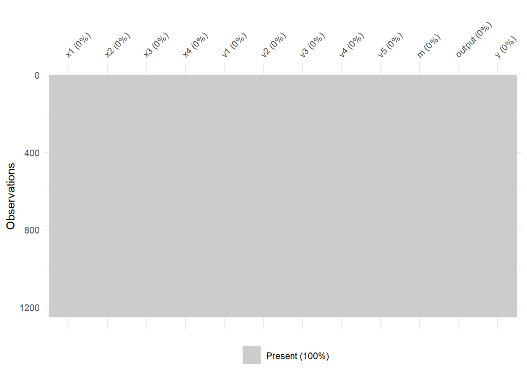

```r
visdat::vis_miss(df)
```

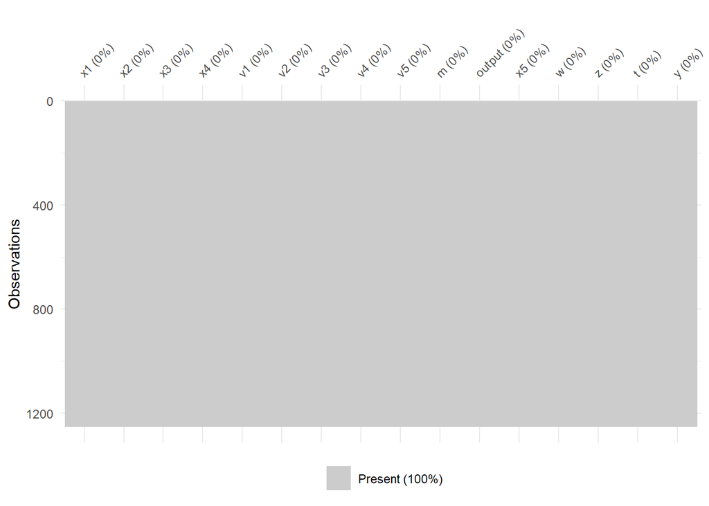

```r
visdat::vis_miss(df_derived)
```

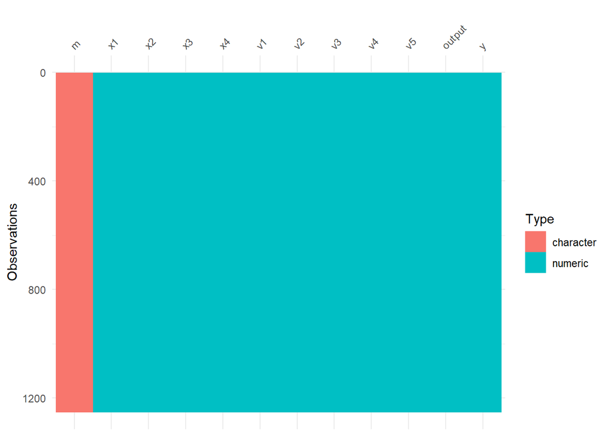

```r
visdat::vis_dat(df)
```

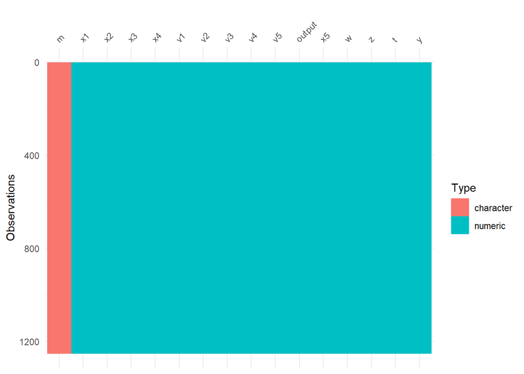

```r
visdat::vis_dat(df_derived)
```

We can see that only one one column `M1` is categorical rest all other features are numeric.

##### Chceking number of distint values of each feature

```r
df %>% purrr::map_dbl(n_distinct)
```

```
##     x1     x2     x3     x4     v1     v2     v3     v4     v5      m output
##   1245   1250   1250   1235   1252   1249   1252   1252   1252      5    690
##      y
##    690
```

```r
df_derived %>% purrr::map_dbl(n_distinct)
```

```
##     x1     x2     x3     x4     v1     v2     v3     v4     v5      m output
##   1245   1250   1250   1235   1252   1249   1252   1252   1252      5    690
##     x5      w      z      t      y
##   1252   1252   1252   1252    690
```

We can see that almost each row is a distinct value of a feature as we have `1252` rows in total and each feature has almost same number of unique values.

So first we will concentrate on the categorical variable `M`.

```r
df %>% count(m)
```

```
## # A tibble: 5 × 2
##   m         n
##   <chr> <int>
## 1 A       227
## 2 B       252
## 3 C       265
## 4 D       260
## 5 E       248
```

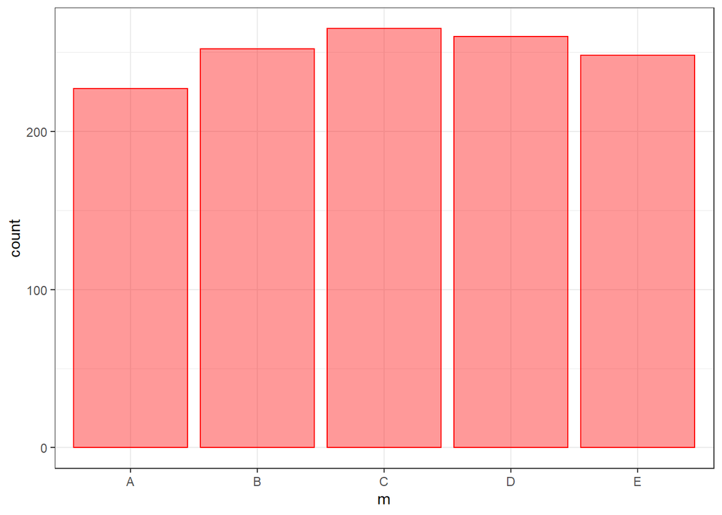

```r
df %>%
  ggplot(mapping = aes(x = m)) +
  geom_bar(color = "red", fill = "red", alpha = 0.4) +
  theme_bw()
```

We can see that the `m` is uniformly distributed.  
Each unique value of `m` has almost same number of observation, so no one particular machine is driving/influencing the data.

##### Checking number of unique combinations of all inputs

```r
df %>%
  select(-output) %>%
  distinct() %>%
  dim()
```

```
## [1] 1252   11
```

```r
df_derived %>%
  select(-output) %>%
  distinct() %>%
  dim()
```

```
## [1] 1252   15
```

There are 1252 unique combinations of input that corresponds to the number of rows of the dataframe, so no input combination is replicated.  
We could also get this by checking the number of unique values of each feature. As each feature had close to `1252` unique values we could have assumed that there are no replications.

### Checking distribution of continuous features

```r
inputs <- c("x1","x2","x3","x4","v1","v2","v3","v4","v5","m")
```

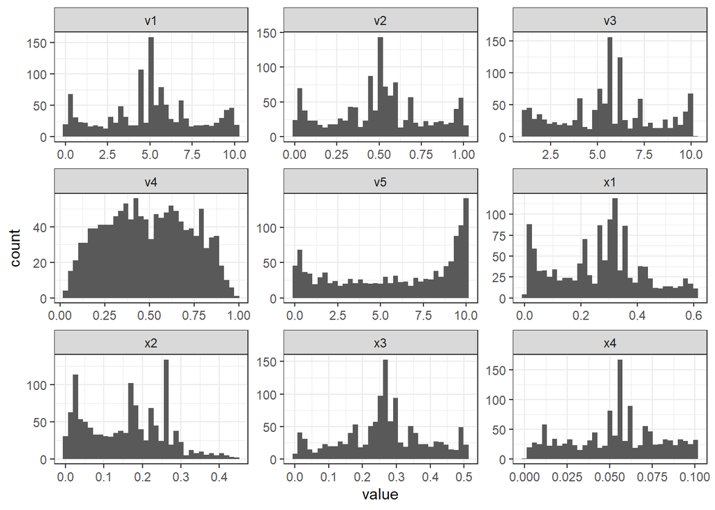

```r
df %>%
  select(all_of(inputs)) %>%
  select(-m) %>%
  tibble::rowid_to_column() %>%
  pivot_longer(!c("rowid")) %>%
  ggplot(mapping = aes(x = value)) +
  geom_histogram(bins = 35) +
  facet_wrap(~name, scales = "free") +
  theme_bw()
```

We can see the variables except **v5**, **x2** looks like a bell-curve.

**We will also check the distribution of the derived inputs.**

```r
inputs_derived <-  c("x5","w","z","t")
```

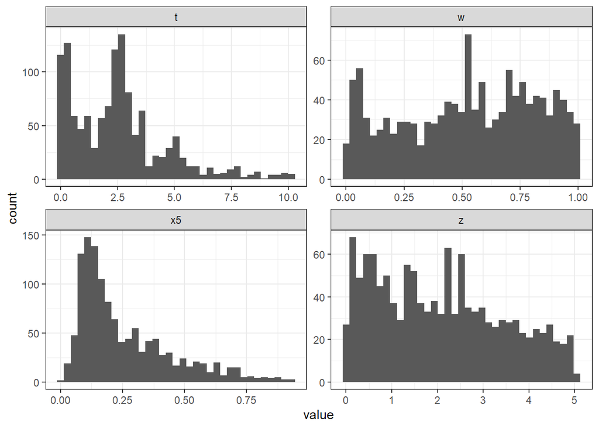

```r
df_derived %>%
  select(all_of(inputs_derived)) %>%
  tibble::rowid_to_column() %>%
  pivot_longer(!c("rowid")) %>%
  ggplot(mapping = aes(x = value)) +
  geom_histogram(bins = 35) +
  facet_wrap(~name, scales = "free") +
  theme_bw()
```

All the derived inputs doesn’t look like Gaussian curve so we will need to apply some sort of transformation before using this features.

We can also check by plotting the density curve.

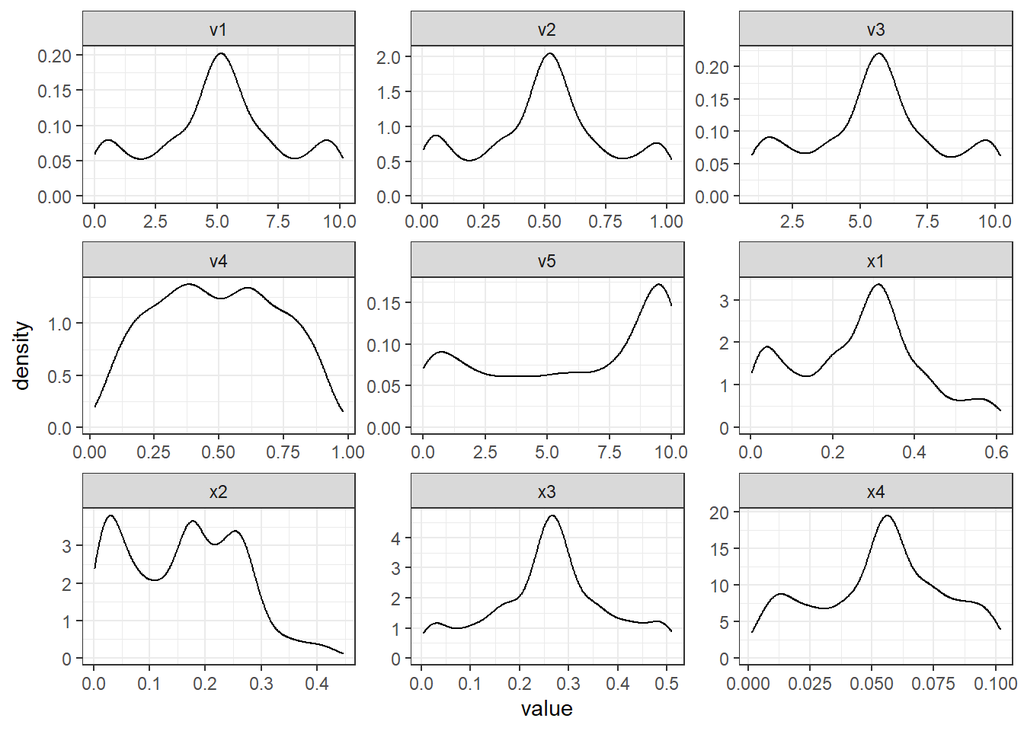

```r
df %>%
  select(all_of(inputs)) %>%
  select(-m) %>%
  tibble::rowid_to_column() %>%
  pivot_longer(!c("rowid")) %>%
  ggplot(mapping = aes(x = value)) +
  geom_density() +
  facet_wrap(~name, scales = "free") +
  theme_bw()
```

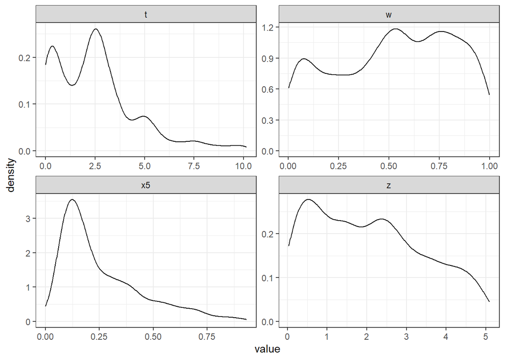

```r
df_derived %>%
  select(all_of(inputs_derived)) %>%
  tibble::rowid_to_column() %>%
  pivot_longer(!c("rowid")) %>%
  ggplot(mapping = aes(x = value)) +
  geom_density() +
  facet_wrap(~name, scales = "free") +
  theme_bw()
```

### Performing Different Transformation to change the feature distribution to Gaussian type

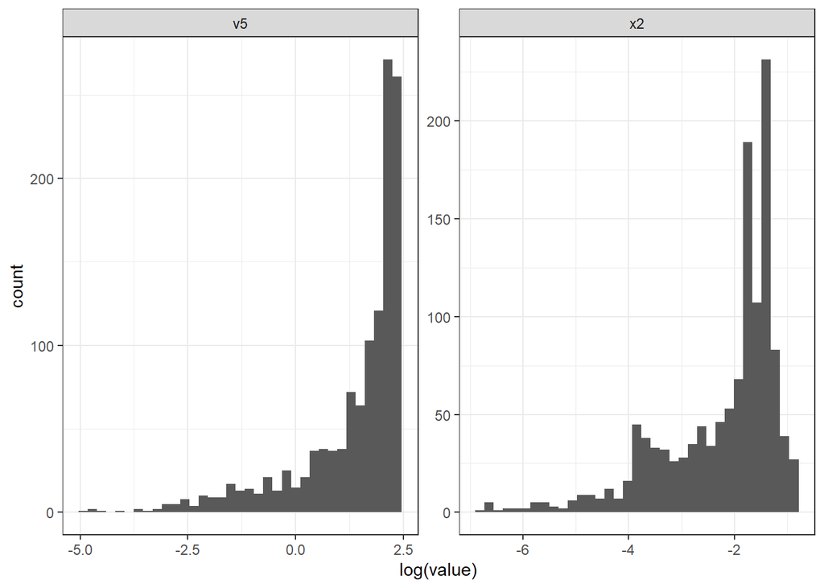

```r
df %>%
  select("x2", "v5") %>%
  tibble::rowid_to_column() %>%
  pivot_longer(!c("rowid")) %>%
  ggplot(mapping = aes(x = log(value))) +
  geom_histogram(bins = 35) +
  facet_wrap(~name, scales = "free") +
  theme_bw()
```

We see that even after performing log-transformation on variables `x2` and `v5` the distribution does not look “Gaussian-like”.

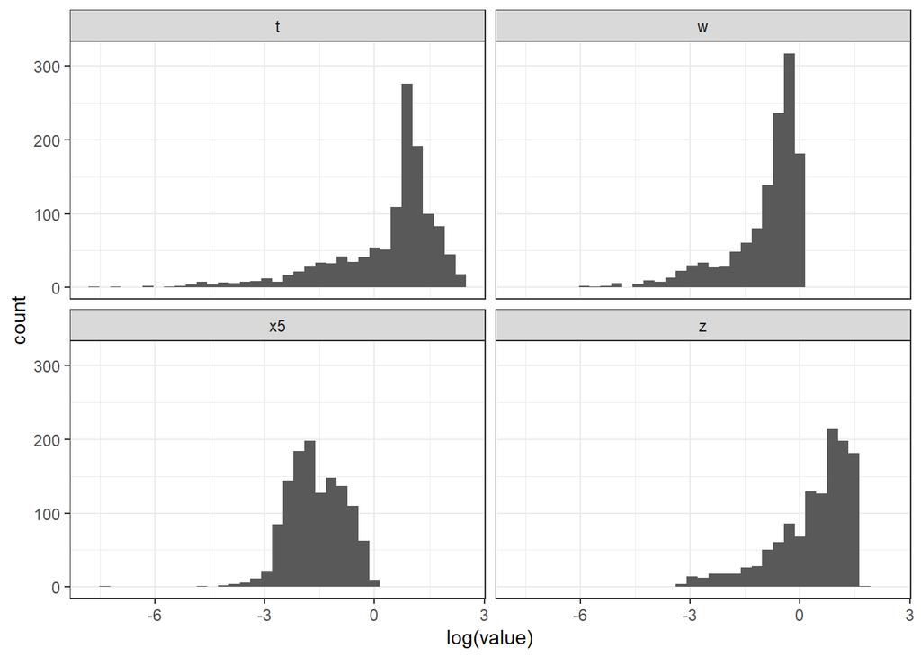

```r
df_derived %>%
  select(all_of(inputs_derived)) %>%
  tibble::rowid_to_column() %>%
  pivot_longer(-rowid) %>%
  ggplot(mapping = aes(x = log(value))) +
  geom_histogram(bins = 35) +
  facet_wrap(~name) +
  theme_bw()
```

Same is true for all the derived features. Even after performing log-transformation the distribution does not look like a Gaussian curve.

**Trying Box-Cox transformation**

```r
lambda_x2 <- forecast::BoxCox.lambda(df$x2, lower = -5, upper = 5)
```

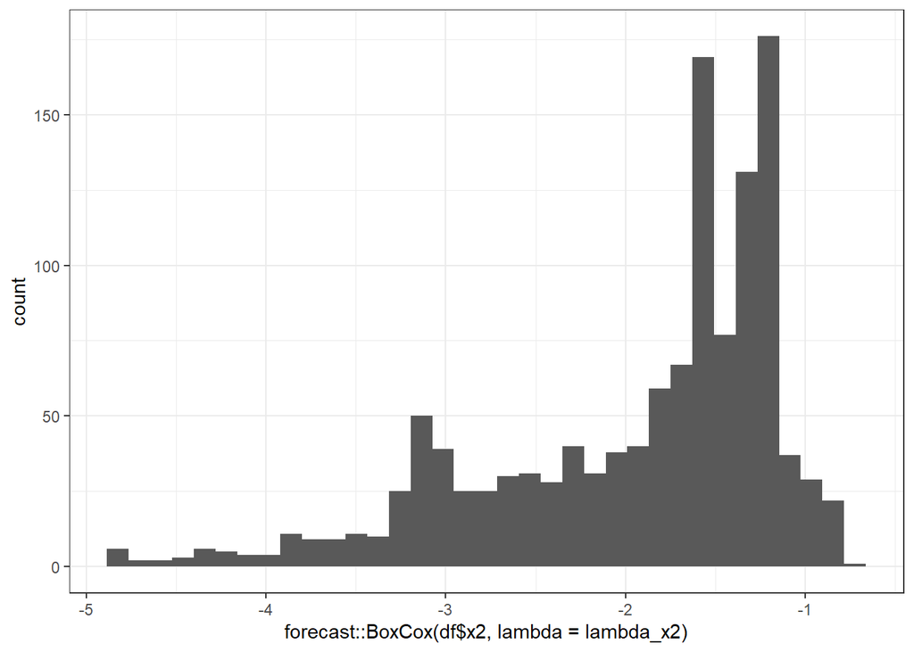

```r
ggplot(mapping = aes(x = forecast::BoxCox(df$x2, lambda = lambda_x2))) +
  geom_histogram(bins = 35) +
  theme_bw()
```

```r
lambda_v5 <- forecast::BoxCox.lambda(df$v5, lower = -5, upper = 5)
```

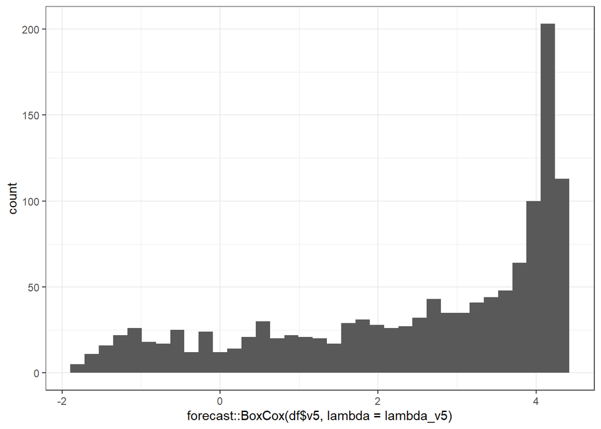

```r
ggplot(mapping = aes(x = forecast::BoxCox(df$v5, lambda = lambda_v5))) +
  geom_histogram(bins = 35) +
  theme_bw()
```

The Box-Cox transformation on `v5` still does not look anything like Gaussian so we will leave `v5` as it is and perform transformation on `x2`.

```r
lambda_x5 <- forecast::BoxCox.lambda(df_derived$x5, lower = -5, upper = 5)
lambda_w <- forecast::BoxCox.lambda(df_derived$w, lower = -5, upper = 5)
lambda_z <- forecast::BoxCox.lambda(df_derived$z, lower = -5, upper = 5)
lambda_t <- forecast::BoxCox.lambda(df_derived$t, lower = -5, upper = 5)
```

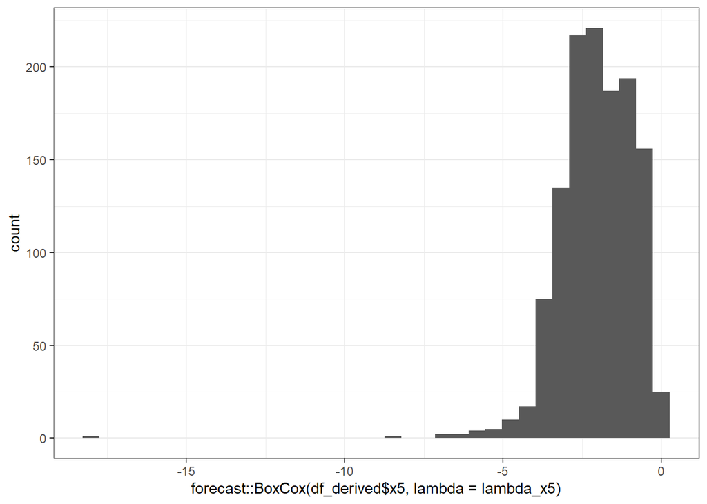

```r
ggplot(mapping = aes(x = forecast::BoxCox(df_derived$x5, lambda = lambda_x5))) +
  geom_histogram(bins = 35) +
  theme_bw()
```

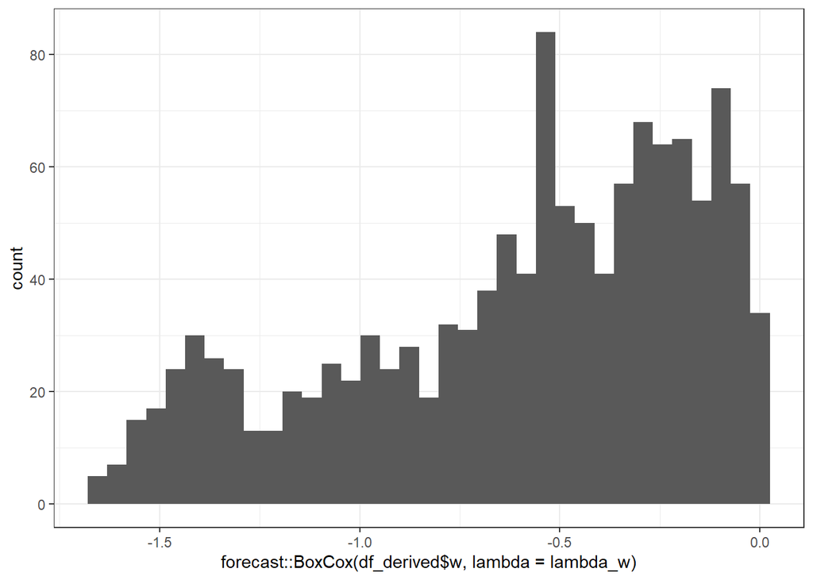

```r
ggplot(mapping = aes(x = forecast::BoxCox(df_derived$w, lambda = lambda_w))) +
  geom_histogram(bins = 35) +
  theme_bw()
```

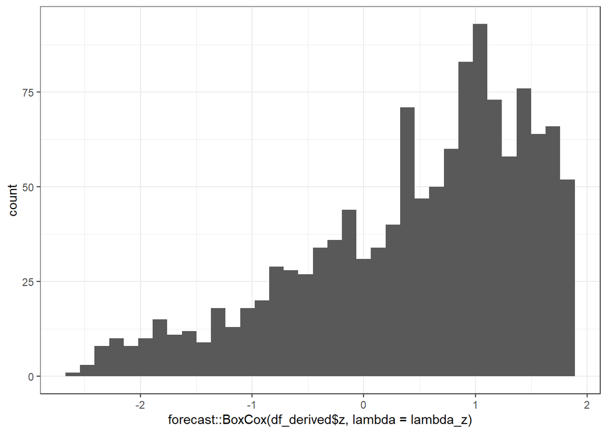

```r
ggplot(mapping = aes(x = forecast::BoxCox(df_derived$z, lambda = lambda_z))) +
  geom_histogram(bins = 35) +
  theme_bw()
```

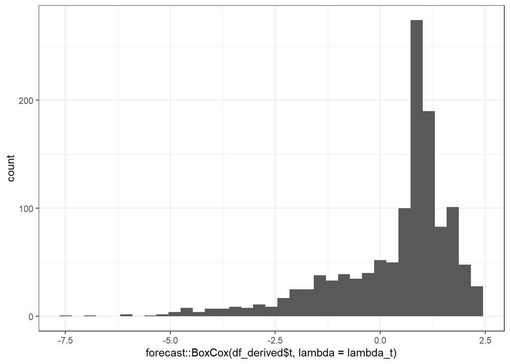

```r
ggplot(mapping = aes(x = forecast::BoxCox(df_derived$t, lambda = lambda_t))) +
  geom_histogram(bins = 35) +
  theme_bw()
```

We will just transform `x2` and keep all the features as it is.

```r
df_t <- df %>%
  mutate(bc_x2 = forecast::BoxCox(x2, lambda = lambda_x2)) %>%
  select(-x2)
```

```r
df_derived_t <- df_derived %>%
  mutate(bc_x2 = forecast::BoxCox(x2, lambda = lambda_x2)) %>%
  select(-x2)
```

##### Scalling all the features

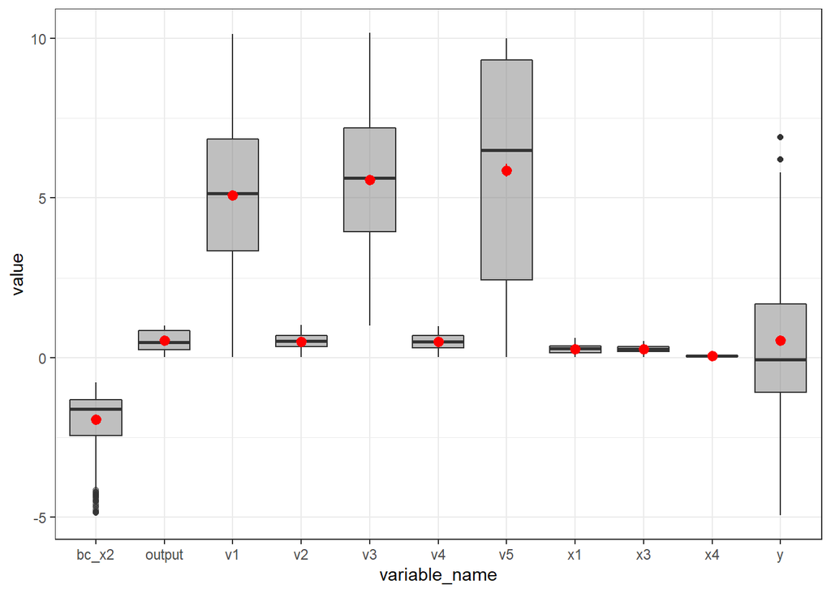

```r
df_t %>%
  tibble::rowid_to_column() %>%
  pivot_longer(-c("rowid","m"), names_to = "variable_name", values_to = "value") %>%
  ggplot(mapping = aes(x = variable_name, y = value)) +
  geom_boxplot(fill = 'grey50', alpha = 0.5) +
  stat_summary(fun.data = 'mean_se',
               fun.args = list(mult = 2),
               color = 'red') +
  theme_bw()
```

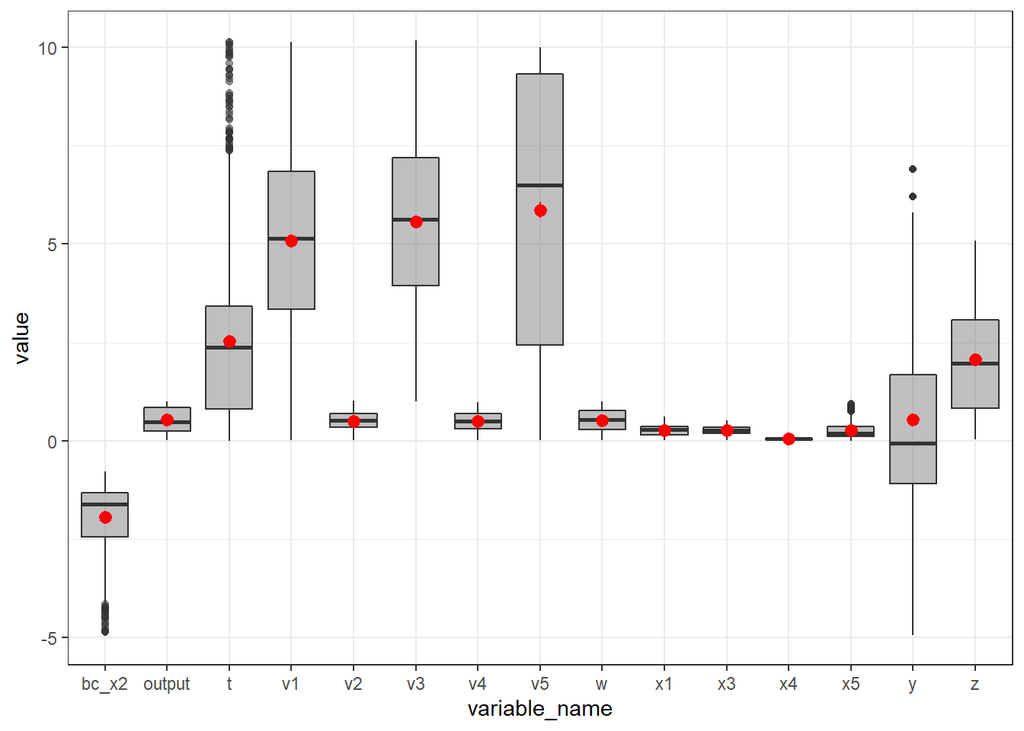

```r
df_derived_t %>%
  tibble::rowid_to_column() %>%
  pivot_longer(-c("rowid","m"), names_to = "variable_name", values_to = "value") %>%
  ggplot(mapping = aes(x = variable_name, y = value)) +
  geom_boxplot(fill = 'grey50', alpha = 0.5) +
  stat_summary(fun.data = 'mean_se',
               fun.args = list(mult = 2),
               color = 'red') +
  theme_bw()
```

From the above figures we can see that the all features are not scaled.

```r
df_scaled <- df_t %>%
  select(-output) %>%
  select(-m) %>%
  scale(center = TRUE, scale = TRUE) %>%
  as.data.frame() %>%
  mutate(m = df$m)
```

```r
df_derived_scaled <- df_derived_t %>%
  select(-m) %>%
  select(-output) %>%
  scale(center = TRUE, scale = TRUE) %>%
  as.data.frame() %>%
  mutate(m = df$m)
```

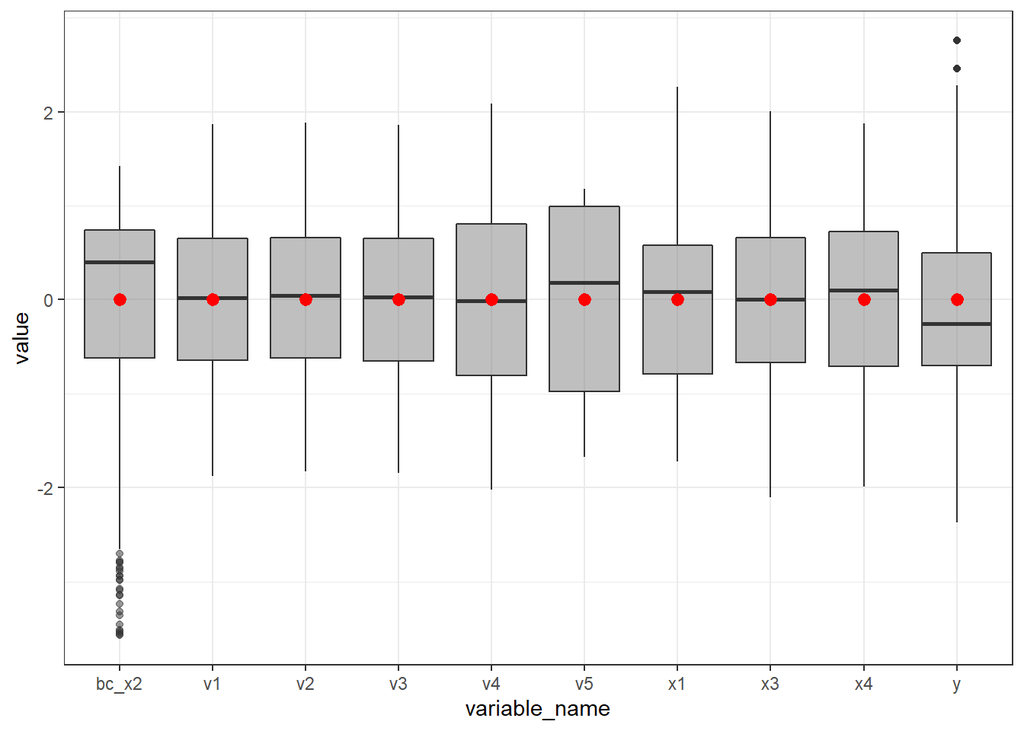

```r
df_scaled %>%
  tibble::rowid_to_column() %>%
  pivot_longer(-c("rowid","m"), names_to = "variable_name", values_to = "value") %>%
  ggplot(mapping = aes(x = variable_name, y = value)) +
  geom_boxplot(fill = 'grey50', alpha = 0.5) +
  stat_summary(fun.data = 'mean_se',
               fun.args = list(mult = 2),
               color = 'red') +
  theme_bw()
```

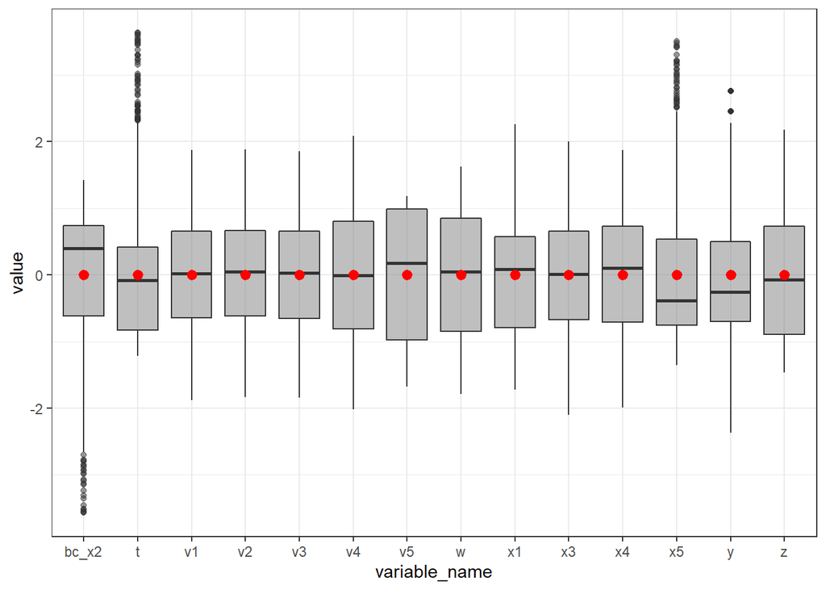

```r
df_derived_scaled %>%
  tibble::rowid_to_column() %>%
  pivot_longer(-c("rowid","m"), names_to = "variable_name", values_to = "value") %>%
  ggplot(mapping = aes(x = variable_name, y = value)) +
  geom_boxplot(fill = 'grey50', alpha = 0.5) +
  stat_summary(fun.data = 'mean_se',
               fun.args = list(mult = 2),
               color = 'red') +
  theme_bw()
```

We can see all the variables are now scaled.

**Grouping the continuous features based on the categorical feature**

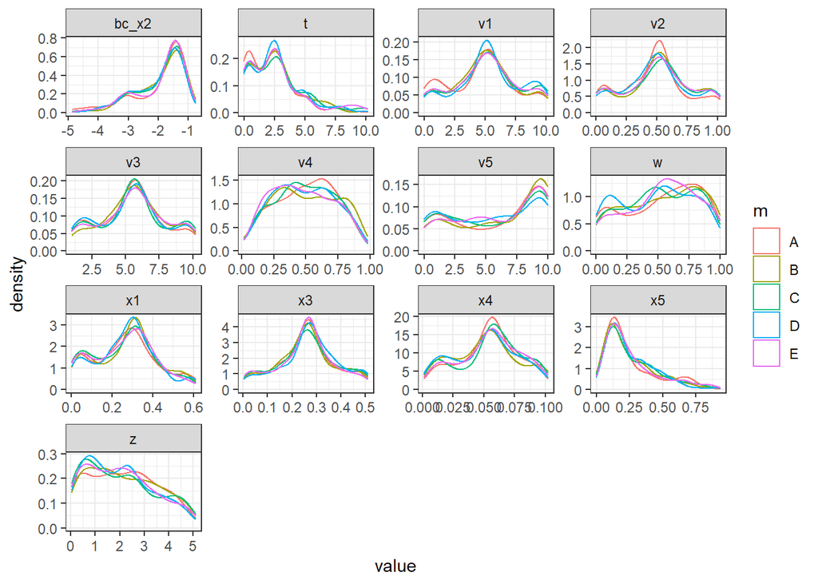

```r
df_derived_t %>%
  tibble::rowid_to_column() %>%
  select(!c("output", "y")) %>%
  pivot_longer(!c("rowid","m")) %>%
  ggplot(mapping = aes(x = value)) +
  geom_density(mapping = aes(color = m)) +
  facet_wrap(~name, scales = "free") +
  theme_bw()
```

We can see that there are no significant changes to the continuous features based on the categorical input **m**.

we can also check the same using the box-plots.

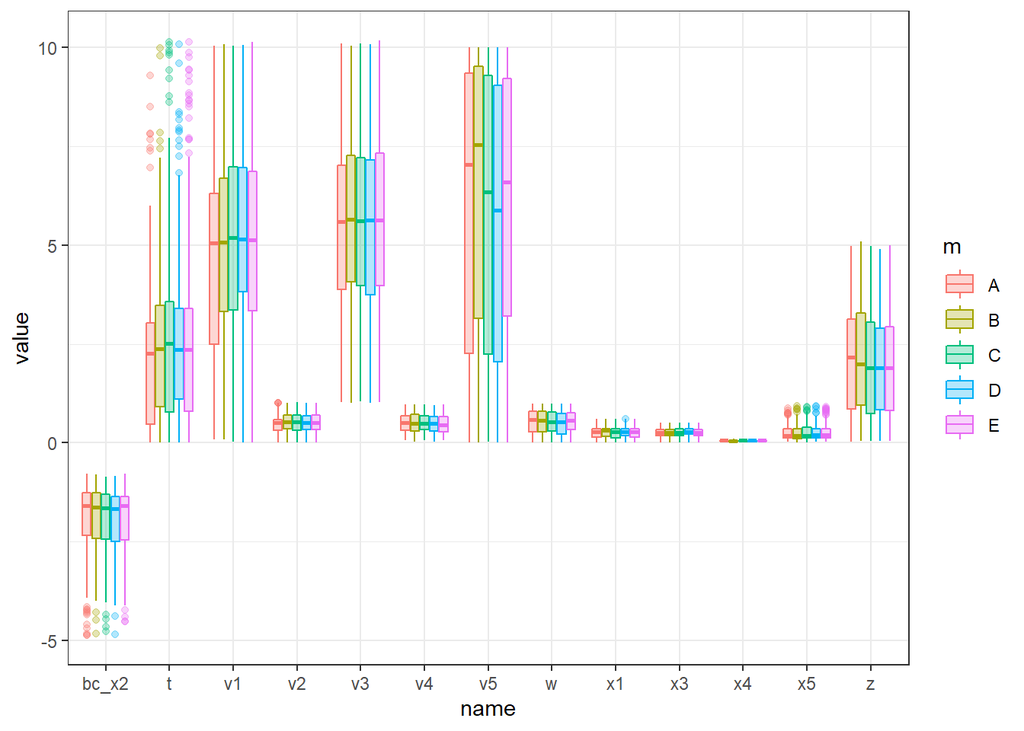

```r
df_derived_t %>%
  tibble::rowid_to_column() %>%
  select(!c("output", "y")) %>%
  pivot_longer(!c("rowid", "m")) %>%
  ggplot(mapping = aes(x = name, y = value)) +
  geom_boxplot(mapping = aes(group = interaction(name, m), fill = m, color = m), alpha = 0.3) +
  theme_bw()
```

**Checking the correlation between the continuous features**

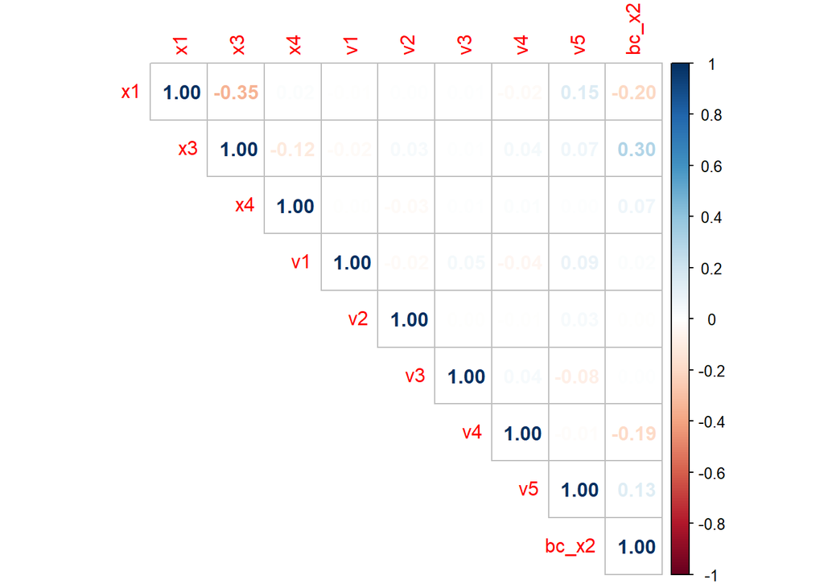

```r
df_t %>%
  select(!c("m", "output", "y")) %>%
  cor() %>%
  corrplot::corrplot(method = "number", type = "upper")
```

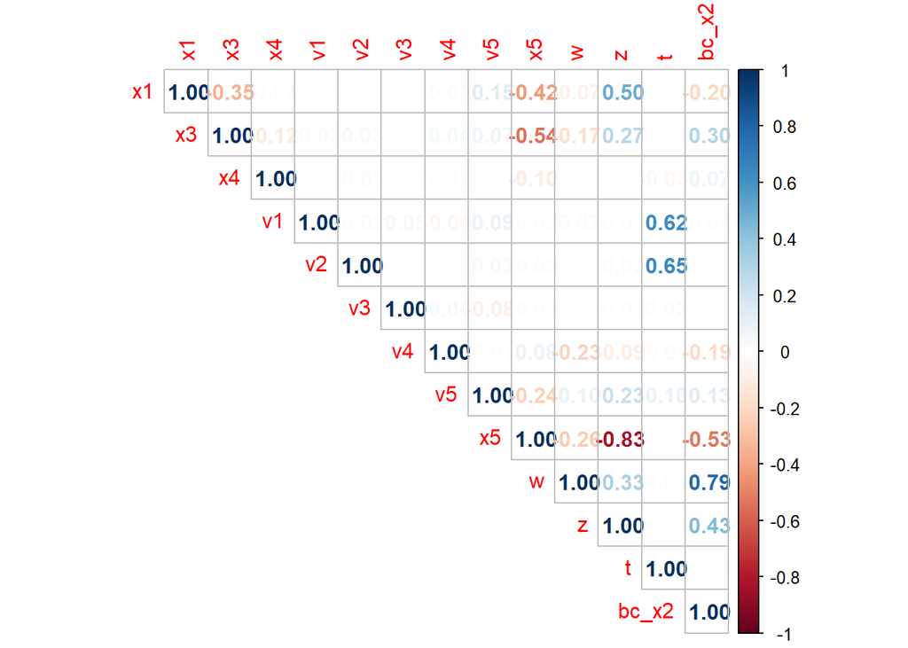

```r
df_derived_t %>%
  select(!c("m", "output", "y")) %>%
  cor() %>%
  corrplot::corrplot(method = "number", type = "upper")
```

We can see that **x5** and **z** are highly anti-correlated.

### Cehcking the distribution of the output repsonse y**

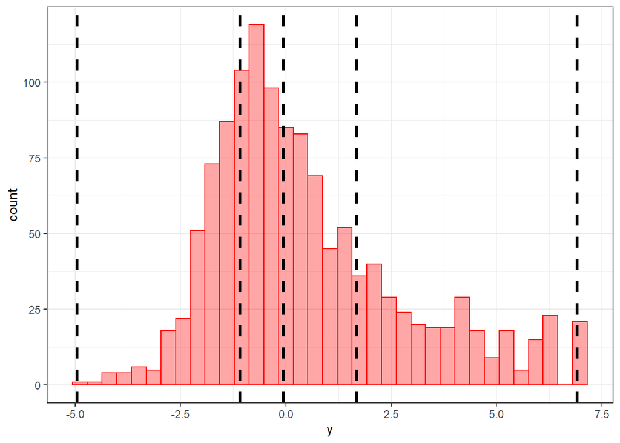

```r
df_t %>%
  ggplot(mapping = aes(x = y)) +
  geom_histogram(bins = 35, color = "red", fill = "red", alpha = 0.35) +
  geom_vline(xintercept = quantile(df$y), linetype = "dashed", size = 1.2) +
  theme_bw()
```

We can see that the response `y` is almost normally distributed.

Checking the response y based on the categorical input m

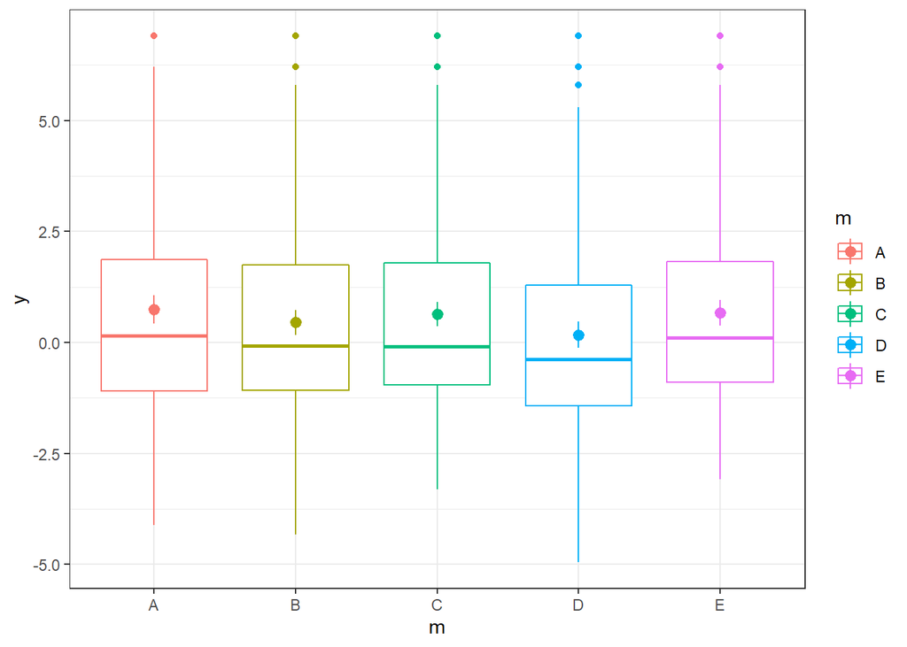

```r
df %>%
  ggplot(mapping = aes(x = m, y = y)) +
  geom_boxplot(mapping = aes(color = m)) +
  stat_summary(fun.data = "mean_se",
               mapping = aes(color = m),
               fun.args = list(mult = 2)) +
  theme_bw()
```

There seems to be no real difference to the value of response `y` based on the categorical input `m`.

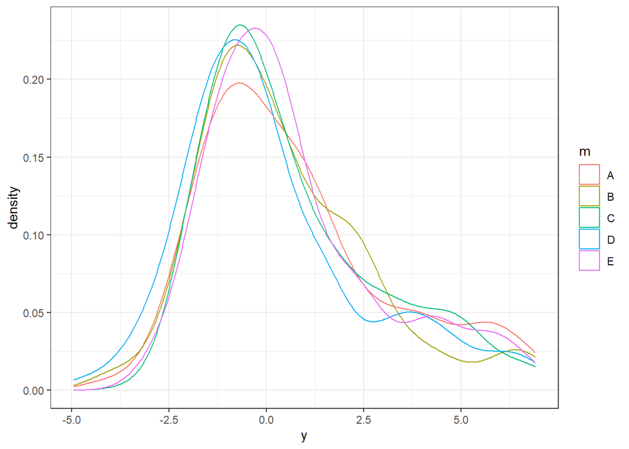

```r
df %>%
  ggplot(mapping = aes(x = y)) +
  geom_density(mapping = aes(color = m)) +
  theme_bw()
```

**Checking the relationship between repsonse with respect to the inputs.

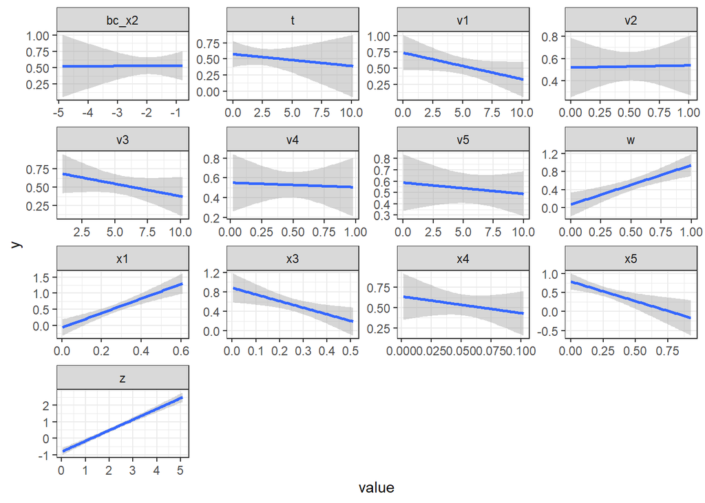

```r
df_derived_t %>%
  select(!c("output","m")) %>%
  tibble::rowid_to_column() %>%
  pivot_longer(!c("rowid", "y")) %>%
  ggplot(mapping = aes(x = value, y = y)) +
  geom_smooth(formula = y ~ x) +
  facet_wrap(~name, scales = "free") +
  theme_bw()
```

Checking based on the categorical input **m**

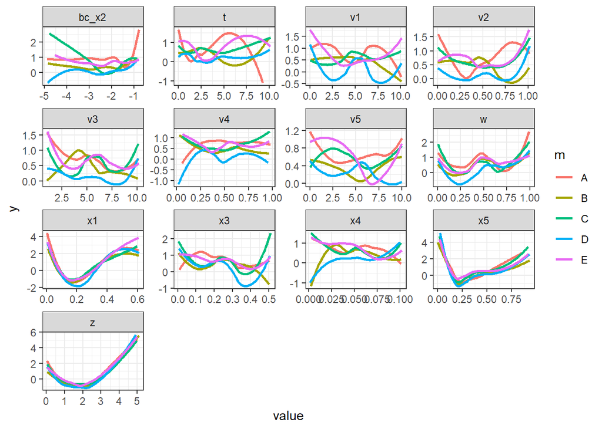

```r
df_derived_t %>%
  select(-output) %>%
  tibble::rowid_to_column() %>%
  pivot_longer(!c("rowid", "m", "y")) %>%
  ggplot(mapping = aes(x = value, y = y)) +
  geom_smooth(mapping = aes(group = m, color = m), formula = y ~ x, se = FALSE) +
  facet_wrap(~name, scales = "free") +
  theme_bw()
```

We cans see that there seems to be some non-linear relationships between the repsonse and the input features when categorized by **m**.